# Εργασία γεωχωρικών δεδομένων - Β Μέρος

10-12-2023

| Φοιτητής | Υπεύθυνος_καθηγητής | ΑΕΜ | email |
| --- | --- | --- | --- |
| Γεώργιος Δημήτριος Γκολογκίνας | κ. Γεώργιος Ευαγγελίδης | aid24004 | aid24004@uom.edu.gr |

Η παρούσα εργασία διαχειρίζεται, επεξεργάζεται, αναλύει, τροποποιεί και οπτικοποιεί γεωχωρικά δεδομένα μέσω του λογισμικού **RStudio**. O φοιτητής καλείται να απαντήσει και να δώσει λύσεις σε μια σειρά προβλημάτων που σχετίζονται τόσο με διανυσματικά όσο και με ψηφιδωτά δεδομένα.

# 1 Ερώτημα - 1

Αρχικά, δόθηκε ενα ψηφιδωτό αρχείο (DEM) το οποίο κάλυπτε αρκετές χώρες, κυρίως στην Νότια Ευρώπη. Στόχος ήταν να απομονωθεί το ψηφιδωτο αρχείο στα όρια - γεωμετρία της Ελλάδας και να αναπαραστεί μέσω διαγράμματος προς επιβεβαίωση του αποτελέσματος.

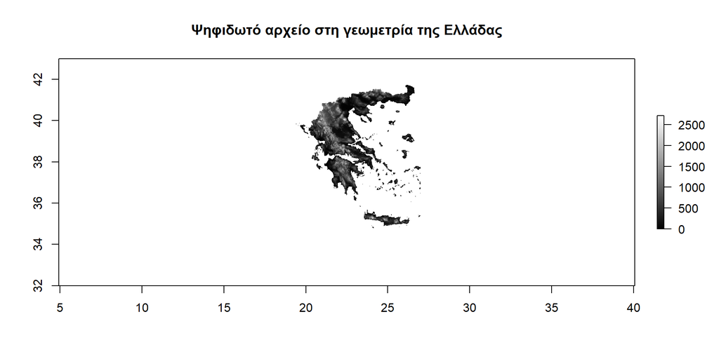

```r
# Get the extent of the clipped raster
raster_extent <- extent(clipped_raster)

# Define the desired zoom extent
desired_zoom_extent <- extent(18, 27, 32, 43)

# Plot the clipped raster with specified color palette and title, and set the plot extent
plot(
  clipped_raster,
  col = grey(1:100/100),
  main = "Ψηφιδωτό αρχείο στη γεωμετρία της Ελλάδας",
  xlim = c(desired_zoom_extent[1], desired_zoom_extent[2]),
  ylim = c(desired_zoom_extent[3], desired_zoom_extent[4])
)

# Add the geometries from the 'poleis' dataset to the plot
plot(poleis$geometry, add = TRUE)
```

## 1.1 Σχολιασμός πρώτου ερωτήματος

Στην παραπάνω χαρτογραφική απεικόνιση φαίνεται το **ψηφιδωτό** αρχείο (DEM) περιορισμένο στη γεωμετρία της Ελλάδας. To νέο ψηφιδωτό αρχείο δημιουργήθηκε με την εντολή **mask**. Συγκεκριμένα δηλώθηκε το αρχικό **DEM** αρχείο και το διανυσματικό αρχείο “Νομοι”, με στόχο τη δημιουργία του νέου ψηφιδωτού στη γεωμετρία του διανυσματικού.

Η διαδικασία αυτή εκτελείται όταν δεν χρειάζεται ολη η πληροφορία, παρα μόνο ένα μέρος της (Ελλάδα). Η μείωση του όγκου βοηθάει στην γρηγορότερη επεξεργασία και ανάλυση των γεωχωρικών δεδομένων που θα δείτε παρακάτω.

# 2 Ερώτημα - 2

Σκοπός του δεύτερου ερωτήματος ήταν να δημιουργηθεί ένας χάρτης που να δείχνει το υψόμετρο κάθε πρωτεύουσας. Το μέγεθος του σημείου που αντιστοιχεί σε κάθε πρωτεύουσα αναλογεί στο υψόμετρο της πρωτεύουσας.

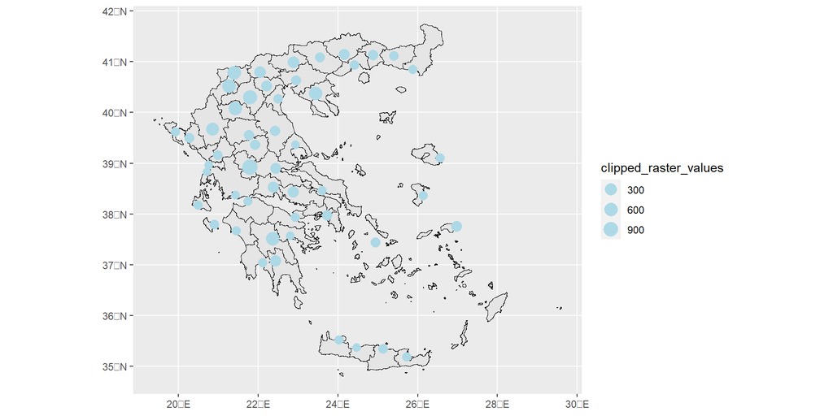

```r
# Extract values from the clipped raster for the 'poleis' dataset
values_poleis <- extract(clipped_raster, poleis)

# Add the extracted values to the 'poleis' dataset as a new column
poleis$clipped_raster_values <- values_poleis

# Create a ggplot object
ggplot() +
  geom_sf(data = nomoi, color = "black") + # Plot geometries from 'nomoi' dataset in black
  geom_sf(data = poleis, aes(size = clipped_raster_values), color = "lightblue") + # Plot 'poleis' with size based on values and lightblue color
  scale_size_continuous(range = c(3, 6)) # Scale the size of points in the plot
```

## 2.1 Σχολιασμός δεύτερου ερωτήματος

Αφου έγινε η απαραίτητη εξαγωγή του υψομέτρου μέσω του ψηφιδωτού αρχείου με την εντολή **extract**,δημιουργήθηκε μια νέα στήλη με το υψόμετρο της κάθε πρωτεύουσας. Στη συνέχεια δημιουργήθηκε ένας θεματικός χάρτης (με τη χρήση της **ggplot**) που για κάθε πρωτεύουσα αντιστοιχεί και ενα διαφορετικό ως προς το μέγεθος σημείο (κύκλος). Αρκετοί χαρτογράφοι - τοπογράφοι χρησιμοποιούν τη συγκεκριμένη μέθοδο, γνωστή ως και μέθοδο Flannery.

Εύκολα παρατηρείται πως πόλεις όπως η Καστοριά, η Φλώρινα και τα Γρεβενά έχουν μεγαλύτερο σημειακό μέγεθος απο πόλεις όπως η Θεσσαλονίκη, η Αθήνα και ο Βόλος, δίνοντας έτσι ένα ξεκάθαρο και γρήγορο συμπέρασμα.

# 3 Ερώτημα - 3

Για το τρίτο ερώτημα χρειάστηκε να υπολογιστεί το μέσο υψόμετρο και η τυπική απόκλιση για κάθε νομό. Τέλος δημιουργήθηκαν 2 χωροπληθείς χάρτες όπου απεικονίζονται τα αποτελέσματα.

Χάρτης **μέσου** υψομέτρου :

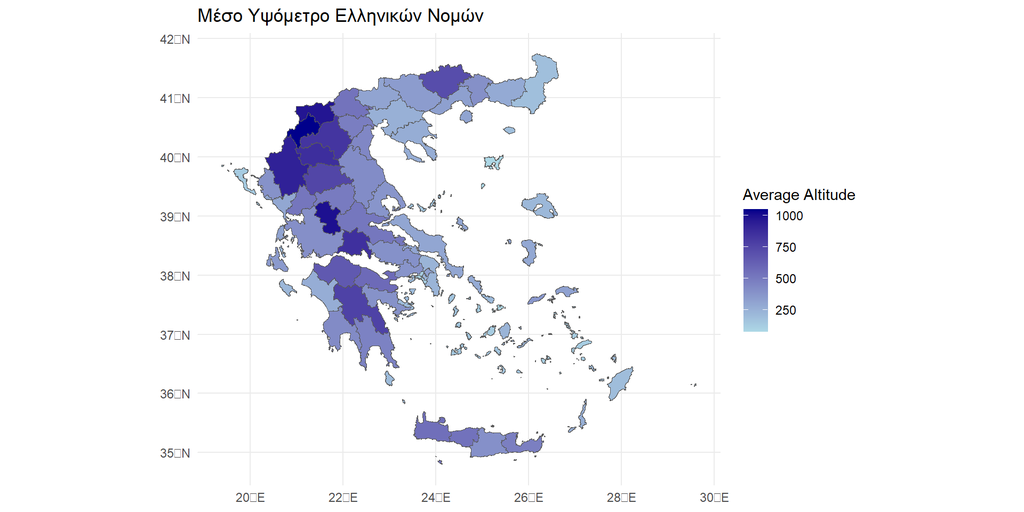

```r
ggplot() +
  geom_sf(data = nomoi, aes(fill = Av_gAltitude)) +
  scale_fill_gradient(name = "Average Altitude", low = "lightblue", high = "darkblue") +
  labs(title = "Μέσο Υψόμετρο Ελληνικών Νομών") +
  theme_minimal()
```

Χάρτης **τυπικής απόκλισης** :

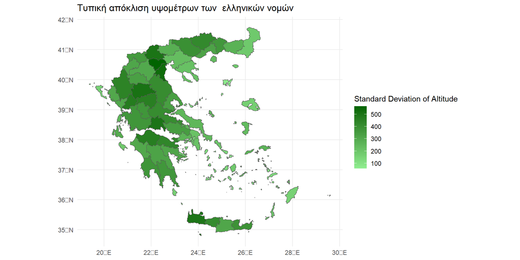

```r
ggplot() +
  geom_sf(data = nomoi, aes(fill = SD_Altitude)) +
  scale_fill_gradient(name = "Standard Deviation of Altitude", low = "lightgreen", high = "darkgreen") +
  labs(title = "Τυπική απόκλιση υψομέτρων των  ελληνικών νομών") +
  theme_minimal()
```

## 3.1 Σχολιασμός τρίτου ερωτήματος

Στους παραπάνω χάρτες φαίνεται η κατανομή του μέσου υψομέτρου καθώς και της τυπικής απόκλισης.

To μέσο υψόμετρο και η τυπική απόκλιση υπολογίστηκαν μέσω της εντολης **extract** με παραμέτρους fun = mean και fun = sd όπως φαίνεται παρακάτω :

altitude_values_mean <- extract(raster_data, nomoi, fun = mean, na.rm = TRUE)  
altitude_values_sd <- extract(raster_data, nomoi, fun = sd, na.rm = TRUE)

Οι χάρτες δημιουργήθηκαν ξανά με τη χρήση της **ggplot**.

Παρατηρείται πως η οροσειρά της Πίνδου και το νησί της Κρήτης ανεβάζουν το μέσο υψόμετρο των περιοχών τους. Αυτό οφείλεται στις οροσειρές που υπάρχουν σε εκείνες τις περιοχές.

Ακόμα, περιοχές όπως η Ημαθία και η Πιερία έχουν μεγάλη τυπική απόκλιση. Αυτό συμβαίνει καθώς στην κάθε περιοχή υπάρχει μεγάλο εύρος τιμών. Για παράδειγμα στα παράλια της Κατερίνης η τιμή του υψομέτρου είναι χαμηλή ενώ τιμές υψηλές υπάρχουν λόγω του Ολύμπου.

# 4 Ερώτημα - 4

Για το τέταρτο ερώτημα χρειάστηκε να εκτελεστεί η διαδικασία συγχώνευσης πεδίων ανάλογα με τη γεωμετρία τους (**Spatial join**), με στόχο τον υπολογισμό της απόλυτης τιμή της διαφοράς του μέσου υψομέτρου του νομού και του υψομέτρου της πρωτεύσουσας του. Τέλος, χρειάστηκε να δημιουργηθεί χάρτης ώστε να αναπαραστούν τα αποτελέσματα.

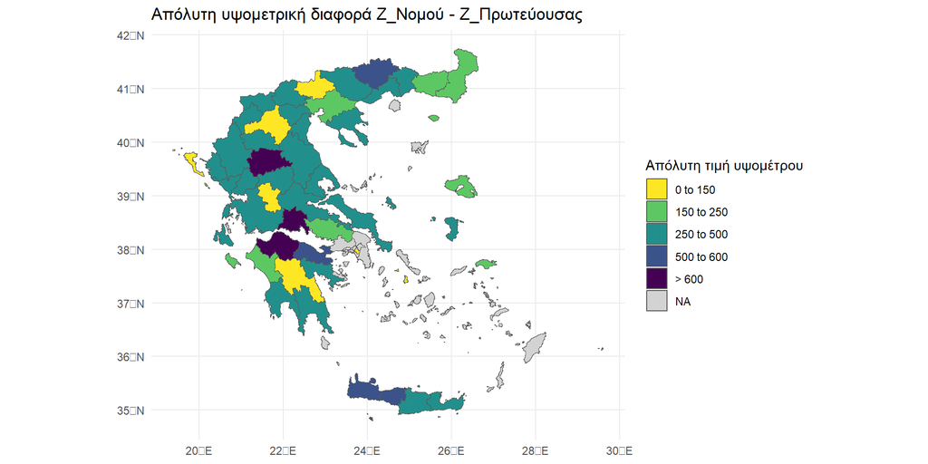

```r
# Transform the 'poleis' dataset to match the coordinate reference system (CRS) of 'nomoi'
poleis_transformed <- st_transform(poleis, st_crs(nomoi))

# Clean invalid geometries in 'poleis' and 'nomoi'
poleis_clean <- st_make_valid(poleis_transformed)
nomoi_clean <- st_make_valid(nomoi)

# Spatially join 'nomoi_clean' and 'poleis_clean' based on intersecting geometries
spatial_joined_data <- st_join(nomoi_clean, poleis_clean, join = st_intersects)

# Calculate the absolute difference between 'clipped_raster_values' and 'Av_gAltitude' and handle NA values
spatial_joined_data$abs_Zn_Zp <- abs(spatial_joined_data$clipped_raster_values - spatial_joined_data$Av_gAltitude)
spatial_joined_data$abs_Zn_Zp[is.na(spatial_joined_data$abs_Zn_Zp)] <- -9999

# Create a categorical variable 'category' based on the absolute difference
spatial_joined_data$category <- cut(
  spatial_joined_data$abs_Zn_Zp,
  breaks = c(-Inf, 0, 150, 250, 500, 600, Inf),
  labels = c("-Inf to 0", "0 to 150", "150 to 250", "250 to 500", "500 to 600", "> 600"),
  include.lowest = TRUE
)

# Order the 'category' factor levels as desired
spatial_joined_data$category <- factor(spatial_joined_data$category, levels = c("NA", "0 to 150", "150 to 250", "250 to 500", "500 to 600", "> 600"))

# Create the main ggplot plot
main_plot <- ggplot() +
  geom_sf(data = spatial_joined_data, aes(fill = category)) +
  scale_fill_viridis(
    name = "Απόλυτη τιμή υψομέτρου",
    discrete = TRUE,
    na.value = "lightgray",
    option = "D",
    direction = -1
  ) +
  labs(title = "Απόλυτη υψομετρική διαφορά Z_Νομού - Ζ_Πρωτεύουσας") +
  theme_minimal()

# Display the main plot
main_plot
```

## 4.1 Σχολιασμός τέταρτου ερωτήματος

Για την εκτέλεση του **spatila join** χρησιμοποιήθηκε η εντολή **st_join**. Για να μπορέσει να γίνει αναπαράσταση των μη διαθέσιμων τιμών στο διάγραμμα, θα πρέπει αυτες οι τιμές να γίνουν αριθμητικές και έπειτα να τους δοθεί ετικέτα με όνομα NA. Έτσι, οι τιμές που θεωρούνται NA δηλώθηκαν ως **-9999** και στο διάγραμμα φαίνονται κανονικά ως NA. Αυτός είναι ένας άτυπος κανόνας για τη διαχείριση αυτών των τιμών. Η οπτικοποίηση έγινε με τη χρήση της **ggplot**.

Παρατηρήθηκε πως οι νομοί είναι 77 ενω οι πρωτεύουσες είναι 51. Αυτομάτως γίνεται αντιληπτό οτι υπάρχουν και μη διαθέσιμες τιμές (NA). Ετσι, δημιουργήθηκε ένας χάρτης με την απόλυτη τιμή της διαφοράς αναπαριστώντας και τις μη διαθέσιμες τιμές (μέρη που δεν υπάρχει διαθέσιμη πληροφορία).

# 5 Ερώτημα - 5

Για το πέμπτο ερώτημα χρειαστηκε να βρεθούν οι 10 υψηλότεροι νομοί ως προς το μέσο υψόμετρο και οι 10 υψηλότεροι νομοί ως προς την τυπική απόκλιση του υψομέτρου.

10 υψηλότεροι νομοί ως προς το μέσο υψόμετρο:

```r
# Get the top 10 rows of 'nomoi' based on the 'Av_gAltitude' column in descending order
top_10_by_mean <- head(nomoi[order(-nomoi$Av_gAltitude), ], 10)

# Convert 'top_10_by_mean' to a data frame
top_10_by_mean = as.data.frame(top_10_by_mean)

# Define the selected columns to keep in the resulting data frame
selected_columns1 <- c("NAME", "feature_id", "Av_gAltitude")

# Create a new data frame 'statistika_top10_ave' containing only the selected columns
statistika_top10_ave <- top_10_by_mean[, c(selected_columns1)]

# Create a table using knitr::kable with a caption
knitr::kable(statistika_top10_ave, caption = "Top 10 Ave")
```

Top 10 Ave

|  | NAME | feature_id | Av_gAltitude |
| --- | --- | --- | --- |
| 75 | Kastoria Regional Unit | 74 | 1046.5366 |
| 47 | Regional Unit of Evrytania | 46 | 992.0511 |
| 20 | Florina Regional Unit | 19 | 972.6403 |
| 67 | Ioannina Regional Unit | 66 | 923.5245 |
| 24 | Grevena Regional Unit | 23 | 862.7185 |
| 60 | Regional Unit of Phocis | 59 | 851.9447 |
| 13 | Regional Unit of Kozani | 12 | 828.5527 |
| 56 | Arcadia Regional Unit | 55 | 768.3817 |
| 64 | Regional Unit of Trikala | 63 | 750.2659 |
| 23 | Drama Regional Unit | 22 | 714.1975 |

10 υψηλότεροι νομοί ως προς την τυπική απόκλιση του υψομέτρου

```r
# Get the top 10 rows of 'nomoi' based on the 'SD_Altitude' column in descending order
top_10_by_stddev_2 <- head(nomoi[order(nomoi$SD_Altitude, decreasing = TRUE), ], 10)

# Convert 'top_10_by_stddev_2' to a data frame
top_10_by_stddev_2 = as.data.frame(top_10_by_stddev_2)

# Define the selected columns to keep in the resulting data frame
selected_columns2 <- c("NAME", "feature_id", "SD_Altitude")

# Create a new data frame 'statistika_top10_sd' containing only the selected columns
statistika_top10_sd <- top_10_by_stddev_2[, c(selected_columns2)]

# Create a table using knitr::kable with a caption
knitr::kable(statistika_top10_sd, caption = "Top 10 SD")
```

Top 10 SD

|  | NAME | feature_id | SD_Altitude |
| --- | --- | --- | --- |
| 50 | Imathia Regional Unit | 49 | 565.4284 |
| 22 | Pieria Regional Unit | 21 | 534.9458 |
| 64 | Regional Unit of Trikala | 63 | 508.8061 |
| 66 | Pella Regional Unit | 65 | 503.1562 |
| 60 | Regional Unit of Phocis | 59 | 500.6029 |
| 18 | Chania Regional Unit | 17 | 496.8949 |
| 14 | Arta Regional Unit | 13 | 471.9222 |
| 43 | Achaea Regional Unit | 42 | 464.1622 |
| 45 | Karditsa Regional Unit | 44 | 459.8503 |
| 67 | Ioannina Regional Unit | 66 | 445.5822 |

## 5.1 Σχολιασμός πέμπτου ερωτήματος

Για το συγκεκριμένο ερώτημα χρησιμοποιήθηκε η εντολή order και δημιουργήθηκαν 2 νέοι πίνακες “dataframes” ώστε να οπτικοποιηθούν.

Στο συγκεκριμένο ερώτημα πραγματοποιήθηκε ένα σορτάρισμα ώστε να αναδειχθούν οι 10 υψηλότεροι νομοί ως προς το μέσο υψόμετρο και οι 10 υψηλότεροι νομοί ως προς την τυπική απόκλιση του υψομέτρου.

Παρατηρείται πως αν και η Φλώρινα εκτείνεται πιο βόρεια απο την Καστοριά, το μέσο υψόμετρο της δεύτερης είναι μεγαλύτερο. Αυτο συμβαίνει καθώς ενδέχεται να υπάρχουν και σημεία όπως πεδιάδες που χαμηλώνουν το μέσο υψόμετρο.

# 6 Ερώτημα - 6

Για το έκτο ερώτημα χρειαστηκε να υπολογιστεί το υψόμετρο για κάθε τοποθεσία και να δημιουργηθεί ένας χάρτης που θα αναδεικνύει τις τοποθεσίες που βρίσκονται άνω των 1500 μέτρων κατηγοριοποιώντας τις ανάλογα με την κατάσταση τους (κατοικημενη ή μη).

Παρακάτω δημιουργήθηκαν 2 χάρτες με στόχο την καλύτερη αντληση πληροφοριών.

1. **Διαδραστικός χάρτης** (click on)

```r
# Extract elevation values from 'raster_data' for 'places' dataset
ypsometro_places <- extract(raster_data, places)

# Add the 'ypsometro' values to the 'places' dataset
places$ypsometro = ypsometro_places

# Filter the data to include only places with elevation greater than 1500 meters
filtered_data <- places[places$ypsometro > 1500, ]

# Define a color palette based on the 'type' column
type_palette <- colorFactor(palette = "Set1", domain = filtered_data$type)

# Create a Leaflet map
map <- leaflet(data = filtered_data) %>%
  addProviderTiles("OpenStreetMap.Mapnik") %>%
  addCircleMarkers(
    radius = 5,
    fillColor = ~type_palette(type),
    fillOpacity = 0.7,
    color = "black",
    stroke = TRUE,
    popup = paste("Type: ", filtered_data$type, "<br>",
                  "Name: ", filtered_data$name, "<br>",
                  "Population: ", filtered_data$population, "<br>",
                  "Ypsometro: ", filtered_data$ypsometro)
  ) %>%
  addLegend("bottomright",
            pal = type_palette,
            values = ~type,
            title = "Type",
            opacity = 0.7)

# Display the Leaflet map
map
```

[interactive chart not shown]

2. **Αναλογικός χάρτης**

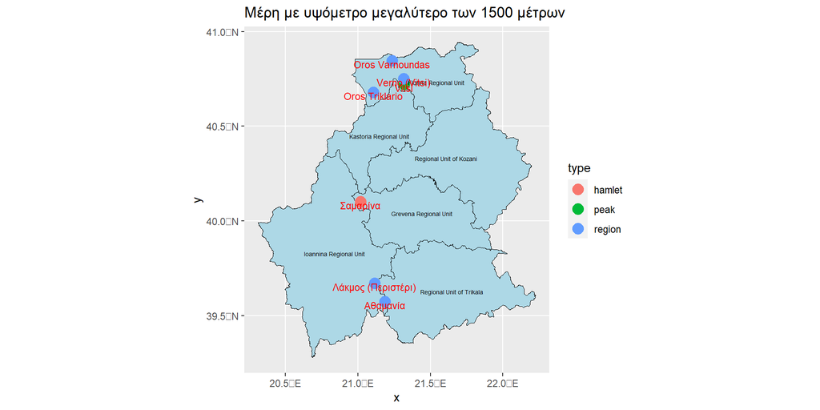

```r
xarths_1500 <- ggplot() +
  geom_sf(data = nomoi_1500, fill = "lightblue", color = "black") +
  geom_sf(data = filtered_data, aes(color = type), size = 4.5) +
  geom_sf_text(data = nomoi_1500, aes(label = NAME), size = 1.8) +
  geom_sf_text(data = filtered_data, aes(label = name), size = 3, color = "red", nudge_y = -0.018) +
  labs(title = "Μέρη με υψόμετρο μεγαλύτερο των 1500 μέτρων")

xarths_1500
```

## 6.1 Σχολιασμός έκτου ερωτήματος

Τέλος, η οπτικοποίηση γίνεται στον πρώτο χάρτη με τη βοήθεια της βιβλιοθήκης **leaflet** ,ενω στο δεύτερο αναλογικό χάρτη με τη χρήση της **ggplot**

Όπως διαπιστώνεται παραπάνω η τοποθεσία που κατοικείται και έχει υψόμετρο μεγαλύτερο των 1500 μέτρων είναι η Σαμαρίνα. Οι υπόλοιπες δεν έχουν πληθυσμό. Στον πρώτο χάρτη που είναι **διαδραστικός**, μπορείτε να **πατήσετε** με τον κέρσορα σας ενα σημείο ωστε να αντλήσετε όλες τις πληροφορίες του.

# 7 Ερώτημα - 7

```r
##############
# Define the desired zoom extent for the plot
#desired_zoom_extent <- extent(18, 27, 32, 43)

# Specify the file path for the clipped raster
#clipped_raster_file <- "clipped_raster.tif"

# Create a raster object from the clipped raster file
#clipped_raster <- raster(clipped_raster_file)

# Define the breaks for reclassification
#breaks <- c(0, 500, 1000, 1500, 2000, 2500, 3000)

# Reclassify the clipped raster based on the specified breaks
#reclassified_raster <- cut(clipped_raster, breaks = breaks)

# Convert the reclassified raster to a data frame with xy coordinates
#raster_df <- as.data.frame(reclassified_raster, xy = TRUE)
#colnames(raster_df) <- c("x", "y", "Category")

# Define colors for each reclassified category
#colors <- c("yellow", "orange", "red", "purple", "blue", "green")

# Create a ggplot to visualize the reclassified raster
#ggplot(raster_df, aes(x = x, y = y, fill = factor(Category))) +
 # geom_raster() +
#  scale_fill_manual(
 #   values = colors,
  #  name = "Category",
   # labels = c("0-500", "500-1000", "1000-1500", "1500-2000", "2000-2500", "2500-3000")
#  ) +
 # labs(title = "Reclassified Raster") +#
#  coord_cartesian(
 #   xlim = c(desired_zoom_extent[1], desired_zoom_extent[2]),
  #  ylim = c(desired_zoom_extent[3], desired_zoom_extent[4])
  #)
```

## 7.1 Σχολιασμός έβδομου ερωτήματος

Οι κατηγορίες δημιουργήθηκαν ως διανυσμα : breaks <- c(0, 500, 1000, 1500, 2000, 2500, 3000)

# 8 Ερώτημα - 8

Για το όγδοο ερώτημα χρειαστηκε να υλοποιήσουμε την ευθεία που ενώνει τα Γρεβενά με τα Ιωάννινα και την ευθεία που ενώνει τη Θεσσαλονίκη με τις Σέρρες. Τέλος υπολογίστηκε το γράφημα του υψομέτρου κατά μήκος αυτών των ευθειών.

**Γρεβενά - Ιωάννινα**

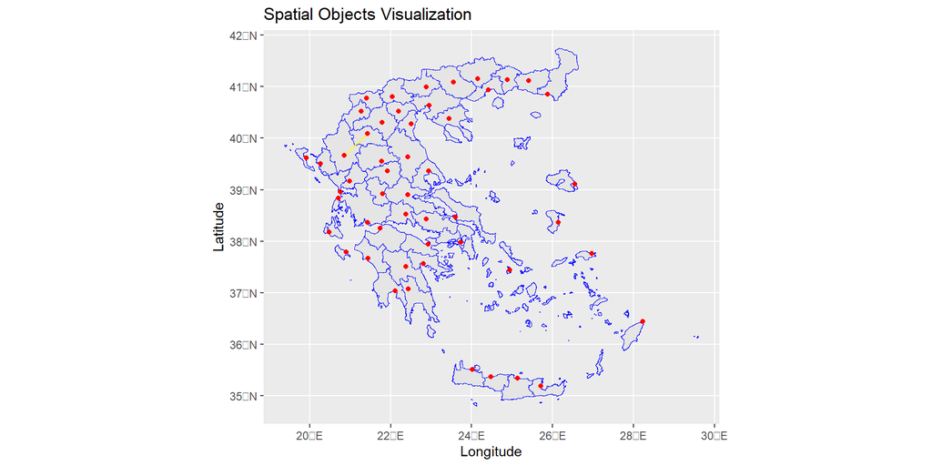

```r
# Define coordinates for Grevena and Ioannina
grevena_coords <- c(280424.6, 4439924)  # Coordinates for Grevena
ioannina_coords <- c(230271.6, 4395427) # Coordinates for Ioannina

# Create points using the coordinates
grevena_point <- st_point(x = matrix(grevena_coords, ncol = 2))
ioannina_point <- st_point(x = matrix(ioannina_coords, ncol = 2))

# Combine points into a linestring representing the line between Grevena and Ioannina
GI_line <- st_sfc(st_linestring(rbind(grevena_point, ioannina_point)))

# Set the CRS for GI_line (assuming it's the same as the 'poleis' dataset)
st_crs(GI_line) <- st_crs(poleis)

# Create an sf object with the geometry
GI_line <- st_sf(geometry = GI_line)

# Create plots using ggplot
p1 = ggplot() +
  geom_sf(data = nomoi, color = "blue") +  # Plot 'nomoi' with blue color
  geom_sf(data = GI_line, color = "yellow") + # Plot 'GI_line' with yellow color
  geom_sf(data = poleis, color = "red") +     # Plot 'poleis' with red color
  labs(x = "Longitude", y = "Latitude") +     # Label axes as needed
  ggtitle("Spatial Objects Visualization")    # Add a title

# Convert the ggplot object to interactive using ggplotly
p1
```

```r
# Generate unique IDs for each point observation in 'GI_line'
GI_line$id <- seq_len(nrow(GI_line))

# Segmentize 'GI_line' into smaller segments with a maximum length of 250 units
GI_line = st_segmentize(GI_line, dfMaxLength = 250)

# Cast the segments into POINT geometries
GI_line = st_cast(GI_line, "POINT")

# Reorder 'GI_line' and assign IDs
GI_line <- GI_line %>%
  st_sf() %>%
  mutate(id = row_number())

# Extract elevation values for 'GI_line' from the clipped raster
GI_elev = terra::extract(clipped_raster, GI_line)
GI_line = cbind(GI_line, GI_elev)

# Load the 'sf' library
library(sf)

# Assuming 'geometry' column contains POINT geometries
# Convert the data frame to an sf object
GI_line_sf <- st_as_sf(GI_line)

# Extract the start point
start_point <- st_geometry(GI_line_sf[1, ])

# Calculate distances between each point and the start point
GI_line$distance <- st_distance(GI_line_sf$geometry, start_point)

# Load the necessary libraries for plotting
library(ggplot2)
library(plotly)

# Convert distance to numeric (assuming it has units attached)
GI_line$distance <- as.numeric(GI_line$distance)

# Create the line plot
p = ggplot(GI_line, aes(x = distance, y = GI_elev, z = id)) +
  geom_line() +
  geom_point() +
  labs(x = "Distance (m)", y = "Elevation") +
  ggtitle("Μηκοτομή Γρεβενών - Ιωαννίνων")

# Create an interactive plot using ggplotly
ggplotly(p)
```

[interactive chart not shown]

**Θεσσαλονίκη - Σέρρες**

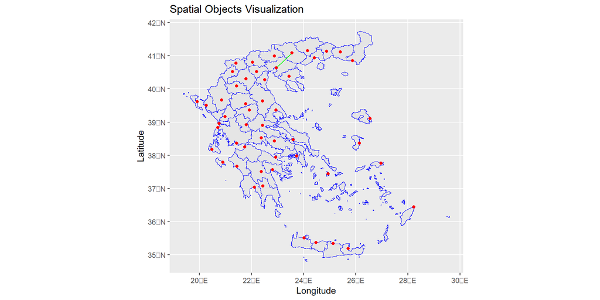

```r
# Define coordinates for Thessaloniki and Serres
thessaloniki_coords <- c(411064.4, 4498812)
serres_coords <- c(462039.3, 4548586)

# Create points using the coordinates
thessaloniki_point <- st_point(x = matrix(thessaloniki_coords, ncol = 2))
serres_point <- st_point(x = matrix(serres_coords, ncol = 2))

# Combine points into a linestring representing the line between Thessaloniki and Serres
TS_line <- st_sfc(st_linestring(rbind(thessaloniki_point, serres_point)))

# Set the CRS for TS_line (assuming it's the same as the 'poleis' dataset)
st_crs(TS_line) <- st_crs(poleis)

# Create an sf object with the geometry
TS_line <- st_sf(geometry = TS_line)

# Create plots using ggplot
p2 = ggplot() +
  geom_sf(data = nomoi, color = "blue") +  # Plot 'nomoi' with blue color
  geom_sf(data = TS_line, color = "green") + # Plot 'TS_line' with green color
  geom_sf(data = poleis, color = "red") +     # Plot 'poleis' with red color
  labs(x = "Longitude", y = "Latitude") +     # Label axes as needed
  ggtitle("Spatial Objects Visualization")    # Add a title

# Display the plot
p2
```

```r
# Generate unique IDs for each point observation in 'TS_line'
TS_line$id <- seq_len(nrow(TS_line))

# Segmentize 'TS_line' into smaller segments with a maximum length of 250 units
TS_line = st_segmentize(TS_line, dfMaxLength = 250)

# Cast the segments into POINT geometries
TS_line = st_cast(TS_line, "POINT")

# Reorder 'TS_line' and assign IDs
TS_line <- TS_line %>%
  st_sf() %>%
  mutate(id = row_number())

# Extract elevation values for 'TS_line' from the clipped raster
TS_elev = terra::extract(clipped_raster, TS_line)
TS_line = cbind(TS_line, TS_elev)

# Load the 'sf' library
library(sf)

# Assuming 'geometry' column contains POINT geometries
# Convert the data frame to an sf object
TS_line_sf <- st_as_sf(TS_line)

# Extract the start point
start_point <- st_geometry(TS_line_sf[1, ])

# Calculate distances between each point and the start point
TS_line$distance <- st_distance(TS_line_sf$geometry, start_point)

# Load the necessary libraries for plotting
library(ggplot2)
library(plotly)

# Convert distance to numeric (assuming it has units attached)
TS_line$distance <- as.numeric(TS_line$distance)

# Create the line plot
p = ggplot(TS_line, aes(x = distance, y = TS_elev, z = id)) +
  geom_line() +
  geom_point() +
  labs(x = "Distance (m)", y = "Elevation") +
  ggtitle("Μηκοτομή Θεσσαλονίκης - Σερρών")

# Create an interactive plot using ggplotly
ggplotly(p)
```

[interactive chart not shown]

## 8.1 Σχολιασμός όγδοου ερωτήματος

Αρχικά, ορίζονται οι συντεταγμένες για τις τοποθεσίες των Γρεβενών. Ιωαννίνων, Θεσσαλονίκης και Σερρών οι οποίες αντλήθηκαν απο το πεδίο geometry του διανυμαστικού αρχείου “poleis”.

Μέσω της εντολης st_sfc(st_linestring(rbind(thessaloniki_point, serres_point))) και TS_line <- st_sf(geometry = TS_line) δημιουργήθηκε η ευθεία που ενώνει τα σημεία ενδιαφέροντος. Έπειτα μέσω της **ggplot** οπτικοποιείται η ευθεία ώστε να ελεγχθεί η αρτιότητα της.

Στη συνέχεια μέσω των εντολών TS_line = st_segmentize(TS_line, dfMaxLength = 250) και TS_line = st_cast(TS_line, “POINT”) δημιουργήθηκαν σημεία επάνω στην ευθεία με απόσταση 250 μέτρα μεταξύ τους. Επιπλέον, μέσω της γνωστής εντολής **extract** υπολογίστηκε το υψόμετρο για κάθε σημείο και η απόσταση του κάθε σημείου απο το αρχικό (όρος :χιλιομετρηκή θέση - ΧΘ)΄με την εντολή st_distance. Τέλος, οπτικοποιήθηκε η μηκοτομή.

Η παραπάνω διαδικασία εκτελέστηκε 2 φορές τόσο για την ευθεία Γρεβενών - Ιωαννίνων όσο και για αυτή μεταξύ Θεσσαλονίκης - Σερρών.

Η δημιουργία **μηκοτομής** (segmentation) σε γεωχωρικά δεδομένα σημαίνει τη διαίρεση ενός γραμμικού τμήματος (όπως ένας δρόμος ή μια διαδρομή) σε μικρότερα τμήματα μήκους ή διακεκομμένα σημεία.

Η μηκοτομή γεωχωρικών τμημάτων είναι μια διαδικασία που συχνά χρησιμοποιείται στη γεωχωρική ανάλυση και διαχείριση δεδομένων. Μεγάλα γεωχωρικά τμήματα μπορούν να χωριστούν σε μικρότερα για ευκολότερη επεξεργασία και διαχείριση. Επίσης, η μηκοτομή μπορεί να βελτιώσει την ακρίβεια σε αναλύσεις ή μετρήσεις, επιτρέποντας την ανάλυση των γεωχωρικών δεδομένων σε πιο λεπτομερή κλίμακα. Επιπλέον, χρησιμοποιείται για τη δημιουργία τμημάτων που αντιστοιχούν σε συγκεκριμένες διαδρομές ή οδούς σε συστήματα πλοήγησης ή ανάλυσης οδών.

Τέλος, χρησιμοποιείται στη διαχείριση υποδομών όπως αγωγοί ή ηλεκτρικές γραμμές, διαιρώντας την υποδομή σε μικρότερα τμήματα για πιο αποτελεσματική συντήρηση και ανάλυση.

# 9 Ερώτημα - 9a

Για το ένατο ερώτημα χρειάστηκε να βρεθούν διανυσματικά και ψηφιδωτά αρχεία που σχετίζονται με την Ελλάδα. Δημιουργήθηκαν τρεις (3) ενδιαφέροντες χάρτες που προέκυψαν από πράξεις πάνω σε διανυσματικά και ψηφιδωτά αρχεία.

Για το πρώτο ερώτημα, έγινε λήψη του διανυμαστικού αρχείου “Corine_2018” που αναπαριστά τις χρήσεις γης στην Ελλάδα. Σκοπός ήταν για κάθε τοποθεσία (places.shp) να δημιουργηθεί ένα νέο πολύγωνο με **buffer** των 100 μέτρων. Έπειτα, να βρεθούν όλες οι χρήσεις γης που υπάρχουν σε κάθε πολύγωνο (κύκλο) και να αναπαρασταθεί το αποτέλεσμα σε έναν **διαδραστικό** χάρτη που ο χρήστης θα έχει τη δυνατότητα να πατήσει σε κάθε πολύγωνο και να μάθει το όνομα της περιοχής και τη χρήση γης.

```r
# Define the CRS for the Greek grid (e.g., GGRS87 or HTRS07)
greek_grid_crs <- "+proj=tmerc +lat_0=0 +lon_0=24 +k=0.9999 +x_0=500000 +y_0=0 +ellps=GRS80 +units=m +no_defs"

# Transform the CRS of 'places' from WGS84 to the Greek grid
places_greek_grid <- st_transform(places, crs = greek_grid_crs)

# Define the buffer size
buffer_size <- 100

# Create a buffer around 'places_greek_grid'
buffered_poleis <- st_buffer(places_greek_grid, dist = buffer_size)

# Reproject 'buffered_poleis' to match the CRS of 'corine'
buffered_poleis <- st_transform(buffered_poleis, st_crs(corine))

# Perform the intersection between 'buffered_poleis' and 'corine'
intersection_buf_cor <- st_intersection(buffered_poleis, corine)

# Assuming the 'name' column has encoding issues, try to change the encoding to UTF-8
intersection_buf_cor$name <- iconv(intersection_buf_cor$name, to = "UTF-8", sub = " ")

# Transform 'intersection_buf_cor' to WGS84 (EPSG:4326)
intersection_buf_cor_wgs84 <- st_transform(intersection_buf_cor, crs = 4326)

# Define a color palette based on 'clc_lege_1' column
color_palette <- colorFactor(palette = "Set1", domain = intersection_buf_cor$clc_lege_1)

# Create a Leaflet map with PopupContent
m <- leaflet() %>%
  addProviderTiles("CartoDB.Positron") %>%
  addPolygons(
    data = intersection_buf_cor_wgs84,
    fillOpacity = 0.7,
    color = ~color_palette(clc_lege_1),
    popup = ~paste(
      "clc_lege_1: ", intersection_buf_cor$clc_lege_1,
      "<br>Name: ", intersection_buf_cor$name,
      "<br>Shape_Area: ", intersection_buf_cor$Shape_Area
    )
  ) %>%
  addTiles()

# Display the map
m
```

[interactive chart not shown]

## 9.1 Σχολιασμός ερωτήματος 9a

Στον παραπάνω **διαδραστικό** χάρτη απεικονίζονται οι χρήσεις γής για όλες τις τοποθεσίες στην Ελλάδα σε μία ακτίνα των 100 μέτρων.

Αρκετά σημεία έχουν παραπάνω απο μία χρήση γης. Ο χρήστης παρακαλείται να μεγεθύνει και να πατήσει με τον κέρσορα του ένα σημείο ώστε να λάβει τις χρήσιμες πληροφορίες που περιέχει (όνομα περιοχής, εμβαδόν, χρήση γης).

Οι εντολές που χρησιμοποιήθηκαν είναι : Για το buffer το **st_buffer** , για τη τομή των πεδίων το **st_intersection** και για την οπτικοποίηση των δεδομένων η βιβλιοθήκη **leaflet**.

# 10 Ερώτημα - 9b

```r
# Simplify the shapefile by reducing vertices within a tolerance of 200 units
simplified_shapefile <- st_simplify(eklogikes_enothtes, dTolerance = 200)

# Transform the simplified shapefile to WGS84 (EPSG:4326)
simplified_shapefile_wgs84 <- st_transform(simplified_shapefile, crs = st_crs("+proj=longlat +datum=WGS84"))

# Extract unique layers from the shapefile
unique_layers <- unique(simplified_shapefile_wgs84$layer)

# Print the unique layers
print(unique_layers)
```

```
## [1] "A_DHMOTIKO_DIAMERISMA"  "B_DHMOTIKO_DIAMERISMA"  "Γ_DHMOTIKO_DIAMERISMA"
## [4] "D_DHMOTIKO_DIAMERISMA"  "E_DHMOTIKO_DIAMERISMA"  "ST_DHMOTIKO_DIAMERISMA"
```

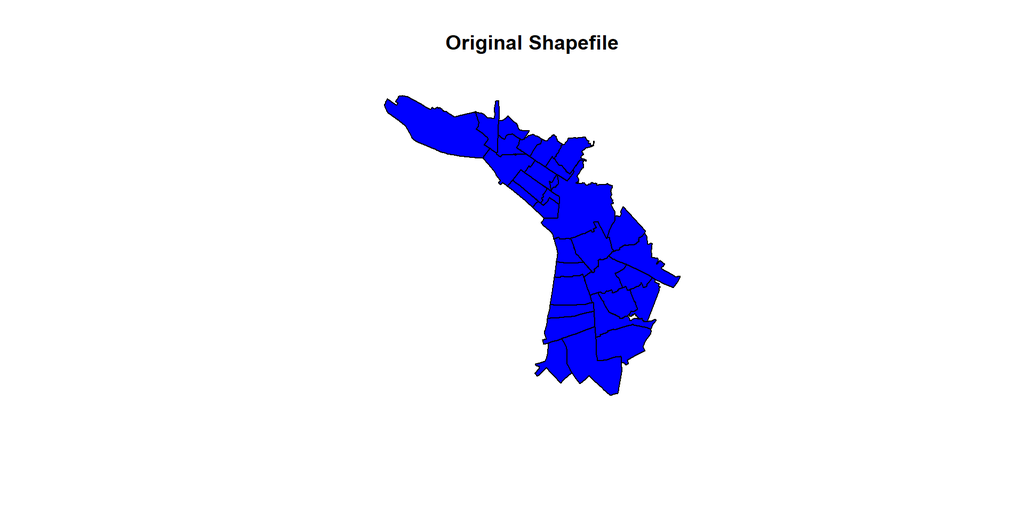

```r
# Create a color palette based on unique values in the 'layer' column
layer_colors <- colorFactor(palette = "Set3", domain = unique_layers)


# Plot the original shapefile (assuming 'eklogikes_enothtes' is the original shapefile)
plot(eklogikes_enothtes$geometry, col = "blue", main = "Original Shapefile")
```

Διασπασμενο πολύγωνο

```r
m <- leaflet() %>%
  addTiles() %>%
  addPolygons(data = simplified_shapefile_wgs84, fillColor = ~layer_colors(layer),
              fillOpacity = 0.8, color = "black", weight = 1,
              popup = paste("", simplified_shapefile_wgs84$EKLOG_DIAM, "<br>",
                            "Δ.Ενοτητα:", simplified_shapefile_wgs84$layer))


m
```

[interactive chart not shown]

## 10.1 Σχολιασμός ερωτήματος 9b

Στη συνέχεια μέσω της εντολής **st_simplify** το ενιαίο διανυσματικό αρχείο δημιουργεί ενα νέο αρχείο αλλά τα όρια των περισσότερων εκλογικών ενοτήτων δεν εφάπτονται. Αυτό δίνει καλύτερη πληροφορία για τα όρια της κάθε εκλογικής ενότητας καθώς και της τοποθεσίας της.

Η τελική διαδραστική οπτικοποίηση δημιουργήθηκε με την βιβλιοθήκη **leaflet** ώστε ο χρήστης να μπορέσει να αντλήσει όλες τις πληροφορίες και παράλληλα να ελέγχει τα όρια της κάθε περιοχής μέσω του υποβάθρου (basemap).

# 11 Ερώτημα - 9c

Για το τελευταίο ερώτημα χρησιμοποιήθηκαν 2 διαφορετικοί τύποι αρχείων. Ενα **ψηφιδωτό** αρχείο το οποίο περιέχει τις τιμές του δείκτη βλάστησης NDVI στην περιοχή της Πτολεμαϊδας και ένα **διανυσματικό** αρχείο που περιέχει αγροτεμάχια στην ίδια περιοχή.

Οι στόχοι ήταν :

1. Οπτικοποίηση των τιμών του δείκτη βλάστησης στα συγκεκριμένα αγροτεμάχια (πριν και μετά την εφαρμογή st_buffer)
2. Εξαγωγή στατιστικών όπως η μεγαλύτερη , η μικρότερη και η μέση τιμή του δείκτη βλάστησης (**NDVI**) για κάθε αγροτεμάχιο.

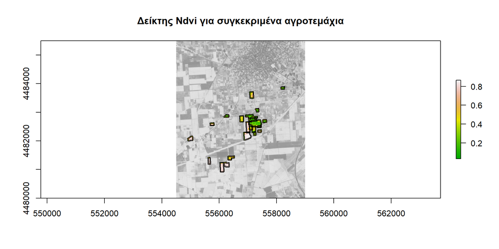

```r
# Define the buffer size for 'agrotemaxia'
buffer_size <- 25

# Create a buffer around 'agrotemaxia'
buffered_agrotemaxia <- st_buffer(agrotemaxia, dist = buffer_size)

# Mask the 'ndvi_rast' raster with 'buffered_agrotemaxia'
raster_agrotem <- mask(ndvi_rast, buffered_agrotemaxia)

# Define the zoom extent
zoom_extent <- extent(554500, 559000, 4480000, 4485500)

# Plot the 'ndvi_rast' raster with grayscale colors
plot(ndvi_rast, col = gray.colors(100), legend = FALSE, main = "Δείκτης Ndvi για συγκεκριμένα αγροτεμάχια", xlim = c(zoom_extent@xmin, zoom_extent@xmax), ylim = c(zoom_extent@ymin, zoom_extent@ymax))

# Plot the 'raster_agrotem' with terrain colors and add it to the previous plot
plot(raster_agrotem, col = terrain.colors(100), main = "Colored Raster", add = TRUE, xlim = c(zoom_extent@xmin, zoom_extent@xmax), ylim = c(zoom_extent@ymin, zoom_extent@ymax))

# Plot the 'buffered_agrotemaxia' geometry on top of the previous plot
plot(buffered_agrotemaxia$geometry, add = TRUE)

# Plot the 'agrotemaxia' geometry on top of the previous plot within the specified zoom extent
plot(agrotemaxia$geometry, add = TRUE, xlim = c(zoom_extent@xmin, zoom_extent@xmax), ylim = c(zoom_extent@ymin, zoom_extent@ymax))
```

```r
# Extract mean NDVI, maximum NDVI, and minimum NDVI values for 'buffered_agrotemaxia'
mean_ndvi <- extract(raster_agrotem, buffered_agrotemaxia, fun = mean)
max_ndvi <- extract(raster_agrotem, buffered_agrotemaxia, fun = max)
min_ndvi <- extract(raster_agrotem, buffered_agrotemaxia, fun = min)

# Add the extracted NDVI values to 'buffered_agrotemaxia' as new columns
buffered_agrotemaxia$mean_ndvi = mean_ndvi
buffered_agrotemaxia$max_ndvi = max_ndvi
buffered_agrotemaxia$min_ndvi = min_ndvi

# Assuming 'buffered_agrotemaxia' contains the necessary columns
selected_columns <- c("Id", "emvadon", "kalliergei", "geometry", "mean_ndvi", "max_ndvi", "min_ndvi")

# Check the column names in 'buffered_agrotemaxia'
colnames(buffered_agrotemaxia)
```

```
##  [1] "Id"          "emvadon"     "kalliergei"  "X2017_kalli" "X2018_kal_r"
##  [6] "X2019_kall"  "X2020"       "X2022_kalli" "paragwgi_2"  "parag_2022"
## [11] "geometry"    "mean_ndvi"   "max_ndvi"    "min_ndvi"
```

```r
# Create a new data frame with selected columns
statistika_agrotemaxiwn <- buffered_agrotemaxia[, c(selected_columns)]

# Create a table using knitr::kable
knitr::kable(statistika_agrotemaxiwn, caption = "Στατιστικά αγροτεμαχίων")
```

Στατιστικά αγροτεμαχίων

| Id | emvadon | kalliergei | geometry | mean_ndvi | max_ndvi | min_ndvi |
| --- | --- | --- | --- | --- | --- | --- |
| 1 | 2.099 | KRAMVI | POLYGON ((556901.8 4482887,… | 0.2784513 | 0.7017662 | 0.03732711 |
| 1 | 1.872 | KRAMVI | POLYGON ((557069.3 4482796,… | 0.2589787 | 0.7068244 | 0.03211708 |
| 1 | 6.811 | KRAMVI | POLYGON ((557112.1 4482699,… | 0.2886001 | 0.7805771 | 0.16144925 |
| 2 | 8.260 | SKLIRO | POLYGON ((557148.6 4482526,… | 0.4462305 | 0.6646028 | 0.23678230 |
| 3 | 1.957 | MALAKO GALIKO | POLYGON ((557164.3 4482282,… | 0.3778547 | 0.6496466 | 0.17065872 |
| 2 | 4.804 | SKLIRO | POLYGON ((557337.1 4482368,… | 0.5073381 | 0.7905167 | 0.18182227 |
| 2 | 3.638 | SKLIRO | POLYGON ((557440.8 4482542,… | 0.3570739 | 0.6518743 | 0.17890128 |
| 2 | 5.003 | SKLIRO | POLYGON ((557186.4 4482303,… | 0.3605967 | 0.5929018 | 0.17670971 |
| 2 | 1.340 | SKLIRO | POLYGON ((556445.8 4481356,… | 0.5446246 | 0.8339362 | 0.13280059 |
| 4 | 2.794 | KALAMPOKI | POLYGON ((556012.4 4481226,… | 0.7002308 | 0.8587341 | 0.17237262 |
| 4 | 1.677 | KALAMPOKI | POLYGON ((556158 4481231, 5… | 0.7844309 | 0.8663090 | 0.37451568 |
| 5 | 9.713 | HLIANTHOS | POLYGON ((555595.7 4481399,… | 0.7320747 | 0.8517947 | 0.28018433 |
| 5 | 1.334 | HLIANTHOS | POLYGON ((554928.8 4481996,… | 0.6916037 | 0.8586816 | 0.19025637 |
| 2 | 1.919 | SKLIRO | POLYGON ((557090.2 4483479,… | 0.4671751 | 0.7467315 | 0.19721773 |
| 3 | 1.792 | MALAKOS AMERIKANIKO | POLYGON ((556863.4 4482687,… | 0.4113653 | 0.7351725 | 0.15841185 |
| 0 | 6.954 | HLIANTHOS | POLYGON ((557512.1 4482724,… | 0.3424021 | 0.7657797 | 0.11204673 |
| 0 | 6.321 | KRAMVI | POLYGON ((557320.2 4482996,… | 0.3590155 | 0.7457973 | 0.16659154 |
| 0 | 4.981 | HLIANTHOS | POLYGON ((558145.2 4483872,… | 0.3216958 | 0.6965417 | 0.05294202 |
| 0 | 5.894 | MALAKO GALIKO | POLYGON ((556184.5 4482819,… | 0.3965047 | 0.8141712 | 0.05855159 |
| 0 | 6.249 | ILIANTHOS | POLYGON ((555705.9 4482524,… | 0.5643594 | 0.7945501 | 0.25847858 |
| 0 | 0.000 | NA | POLYGON ((556919.3 4482649,… | 0.6868371 | 0.8563689 | 0.27401552 |
| 0 | 0.000 | NA | POLYGON ((556841.2 4482285,… | 0.7554519 | 0.8662799 | 0.25638378 |

## 11.1 Σχολιασμός ερωτήματος 9c

Αρχικά για κάθε αγροτεμάχιο δημιουργήθηκε ένα buffer με την εντολή **st_buffer**.

Με την εντολή **mask**(ndvi_rast, buffered_agrotemaxia) δημιουργήθηκε το νέο ψηφιδωτό αρχείο για τις περιοχές που καλύπτουν τα αγροτεμάχια. Έπειτα για την αντληση των τιμών του ψηφιδωτού αρχείου χρησιμοποίηθηκε η εντολή **extract** όπου υπολογίστηκαν οι μεγαλύτερες, οι μικρότερες και οι μέσες τιμές του δείκτη.

Ο δείκτης βλαστησης NDVI (Normalized Difference Vegetation Index) είναι ένας αποδεκτός δείκτης που χρησιμοποιείται ευρέως στον τομέα της ψηφιακής επεξεργασίας εικόνων και της γεωγραφικής πληροφορικής για την αξιολόγηση της φυτικής βλάστησης σε διάφορες περιοχές. Ο NDVI υπολογίζεται από προσανατολισμένες φωτογραφίες από δορυφόρους ή από αεροφωτογραφίες και κυματομορφές φάσεις από την περιοχή που εξετάζεται.

Χρησιμοποιεί τη διαφορά μεταξύ της ανακλώμενης ακτινοβολίας στο κοντινό υπέρυθρο (NIR) και της ανακλώμενης ακτινοβολίας στο κοντινό κόκκινο (RED). Ο NDVI κυμαίνεται από **-1 έως +1**, με υψηλές τιμές να υποδηλώνουν πυκνή και υγιή βλάστηση, ενώ χαμηλές τιμές υποδηλώνουν ελλιπή ή ανεπαρκή βλάστηση.

**Σημείωση** : Για περισσότερες λεπτομέρεις ως προς την υλοποίηση των ερωτημάτων, παρακαλείσθε να ανατρέξετε στον κώδικα που παραδόθηκε σε μορφή Rmarkdown με όνομα B_meros_Geospatial_Gkologkinas_George.Rmd

```
                                             Θεσσαλονίκη 10-12-2023

                                         Γεώργιος Δημήτριος Γκολογκίνας

                                    Υπεύθυνος καθηγητής : κ.Γεώργιος Ευαγγελίδης
```